# PRV - 4 cell lines: TES dynamics

### Finding the optimal number of clusters to cut the tree at and calculate

#### Clustering statistics: Cluster number: 5

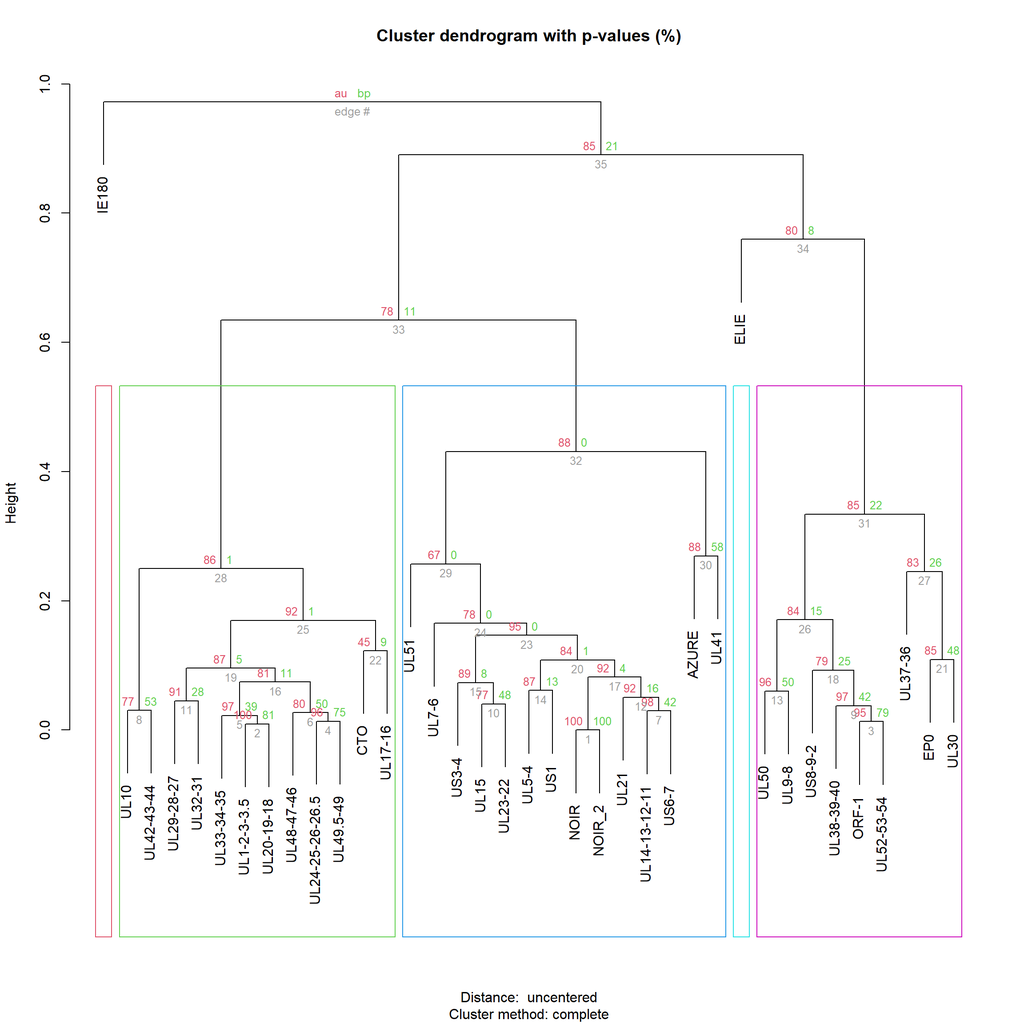

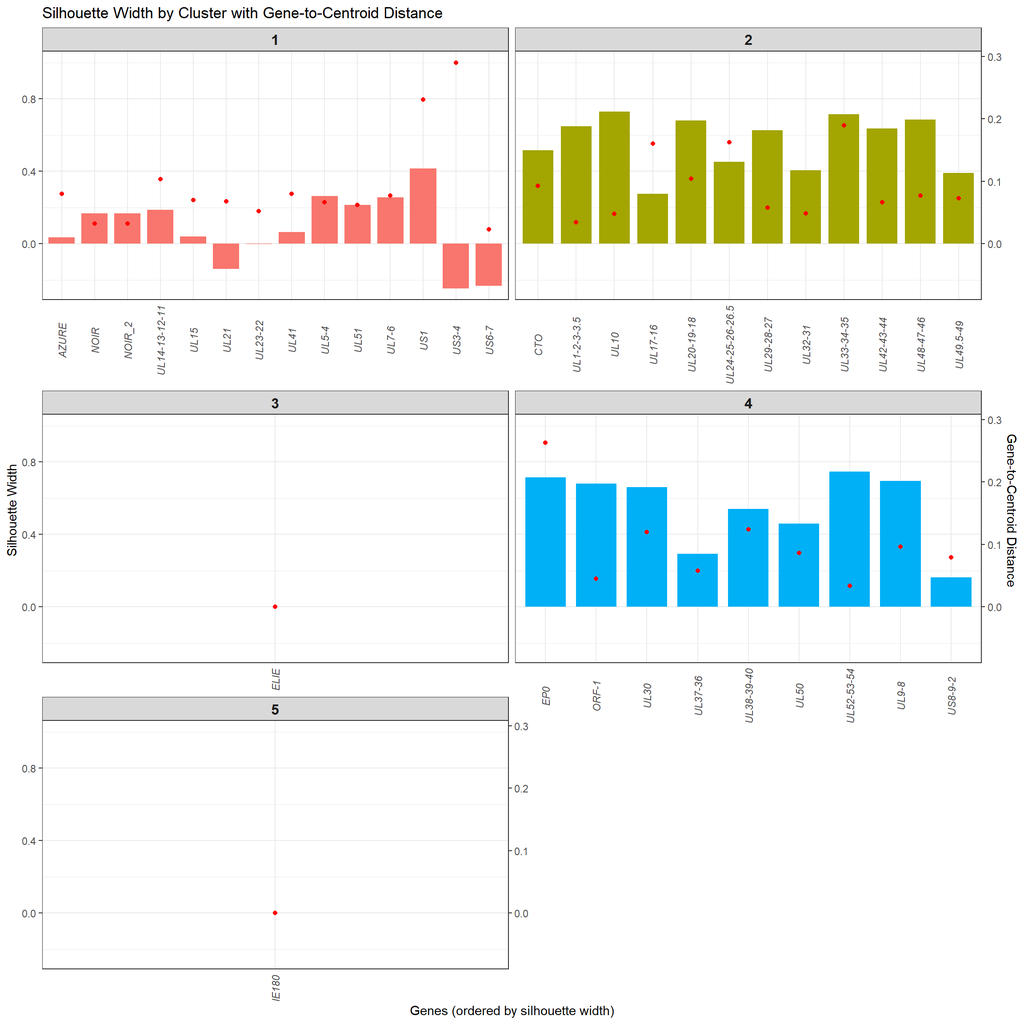

```
## Unclustered Genes, based on a Silhouette threshold of 0 and a Scaled Distance of 20:
## UL23-22
## UL21
## US6-7
## US3-4
```

```
## Unclustered Genes, based on AU threshold of 0.95:
## ELIE
```

#### Clustering statistics: Cluster number: 6

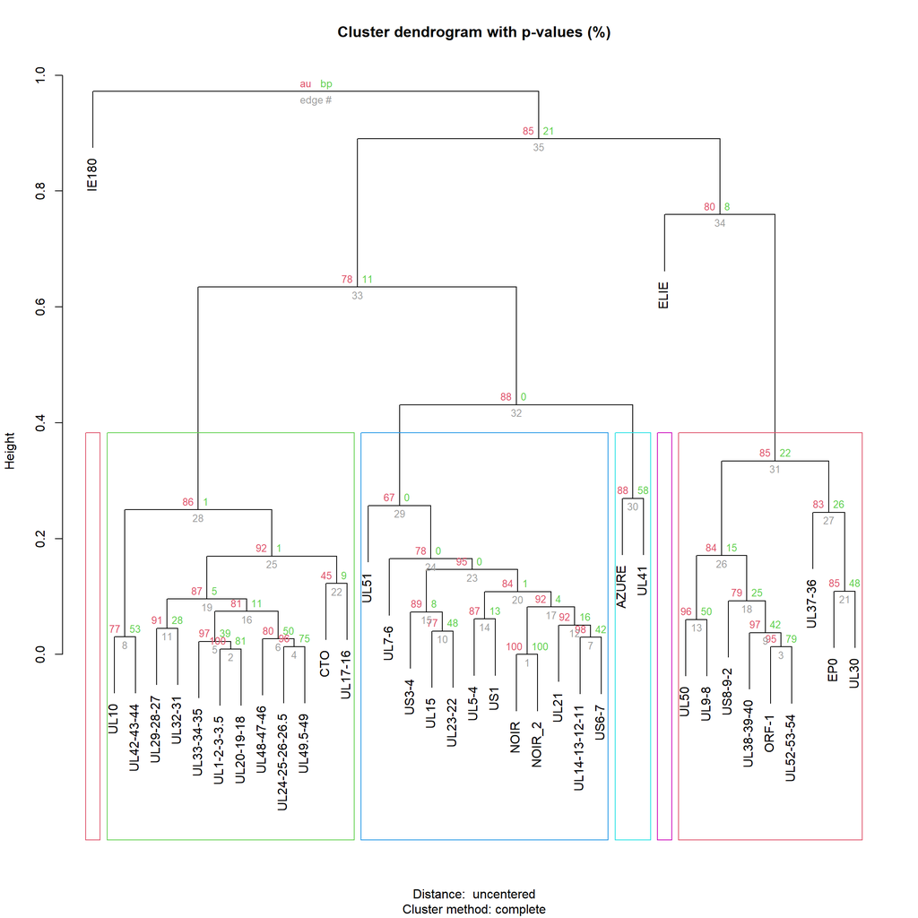

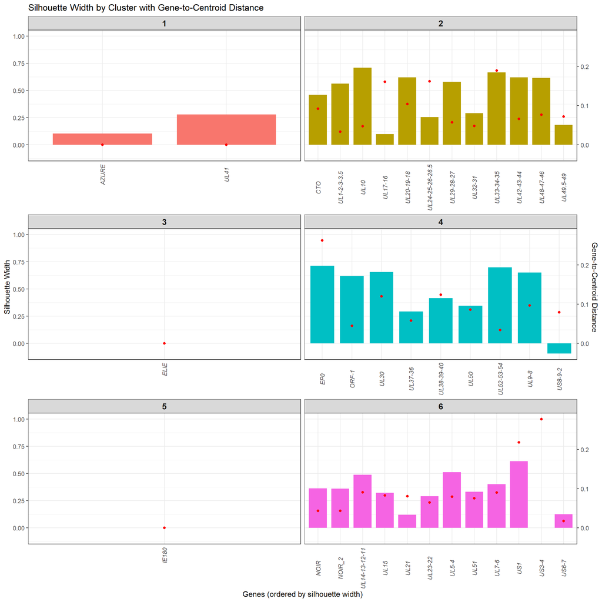

```
## Unclustered Genes, based on a Silhouette threshold of 0 and a Scaled Distance of 20:
## US8-9-2
## US3-4
```

```
## Unclustered Genes, based on AU threshold of 0.95:
## ELIE
## NOIR
## NOIR_2
## UL14-13-12-11
## UL15
## UL21
## UL23-22
## UL5-4
## UL51
## UL7-6
## US1
## US3-4
## US6-7
```

#### Clustering statistics: Cluster number: 7

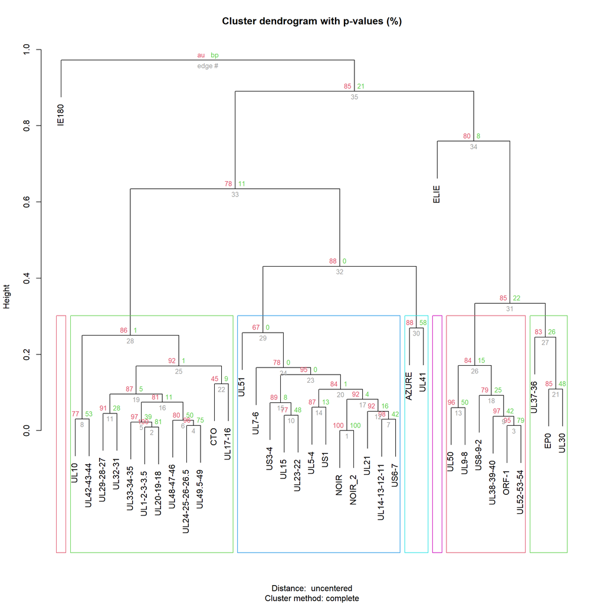

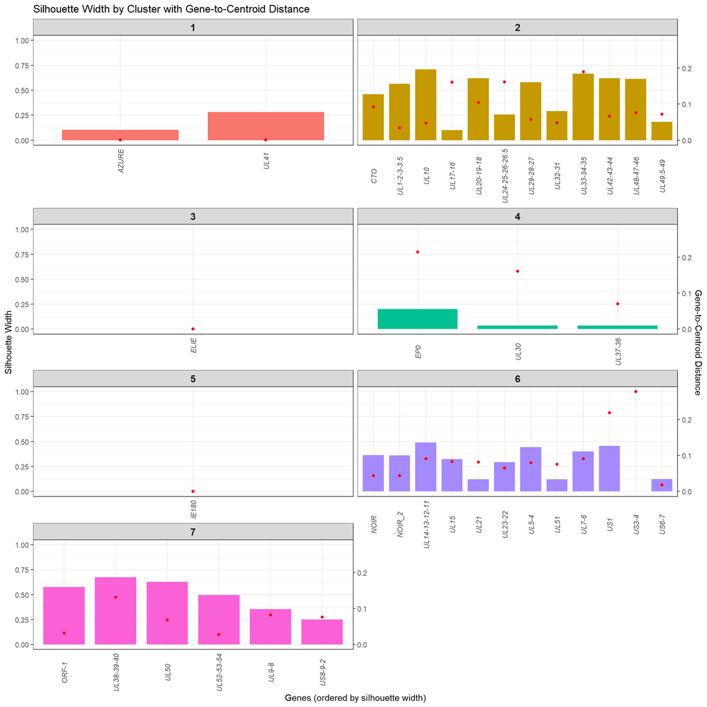

```
## Unclustered Genes, based on a Silhouette threshold of 0 and a Scaled Distance of 20:
## US3-4
```

```
## Unclustered Genes, based on AU threshold of 0.95:
## ELIE
## NOIR
## NOIR_2
## UL14-13-12-11
## UL15
## UL21
## UL23-22
## UL5-4
## UL51
## UL7-6
## US1
## US3-4
## US6-7
```

#### Clustering statistics: Cluster number: 8

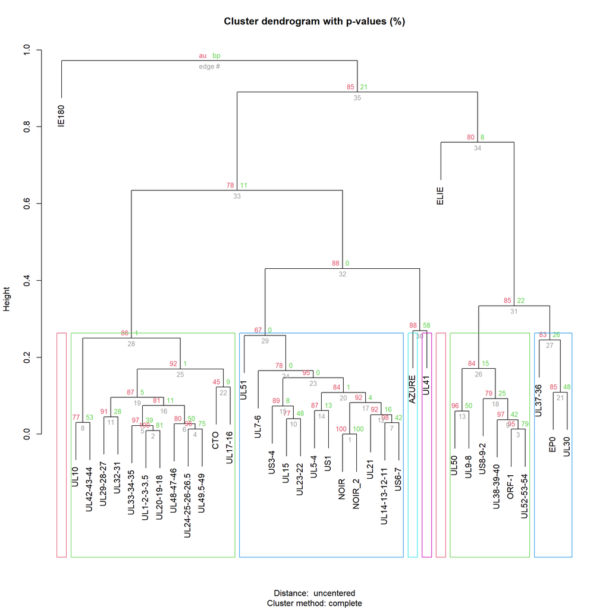

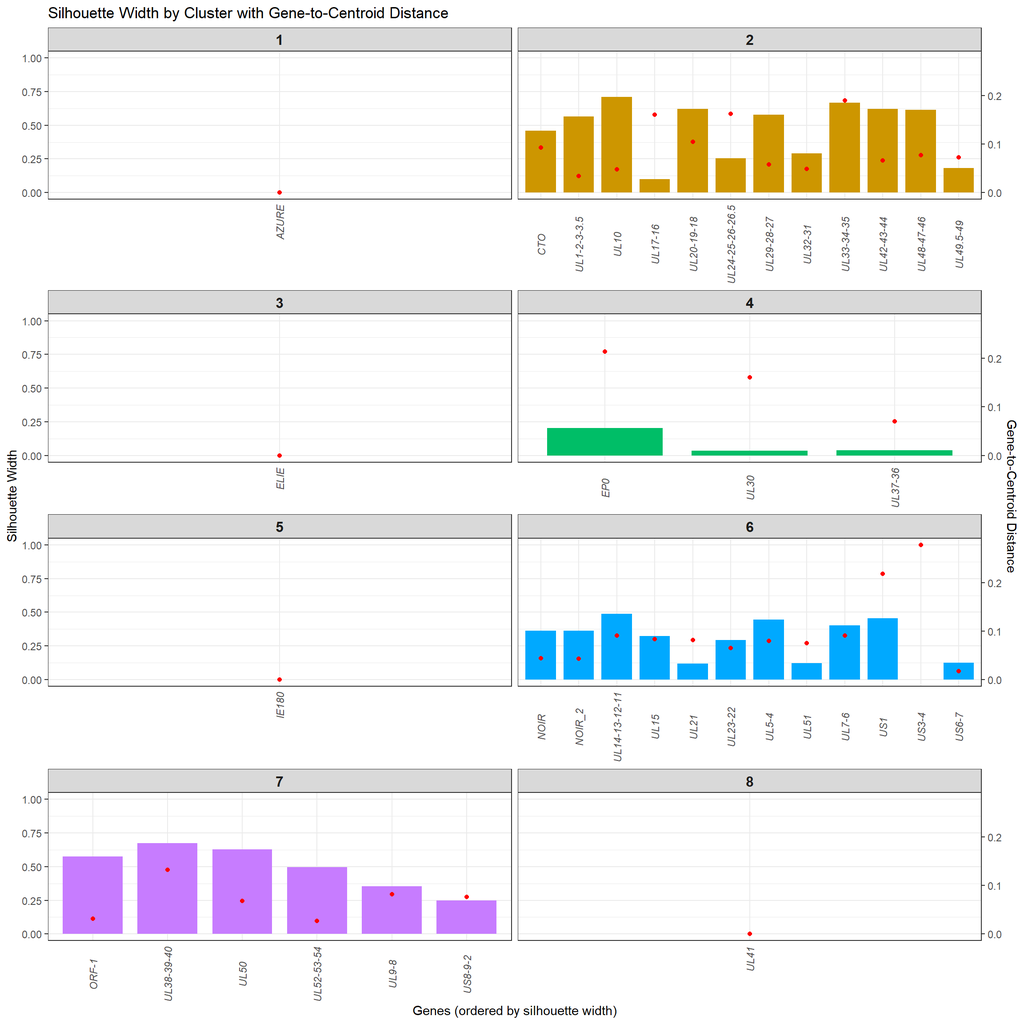

```
## Unclustered Genes, based on a Silhouette threshold of 0 and a Scaled Distance of 20:
## US3-4
```

```
## Unclustered Genes, based on AU threshold of 0.95:
## ELIE
## NOIR
## NOIR_2
## UL14-13-12-11
## UL15
## UL21
## UL23-22
## UL5-4
## UL51
## UL7-6
## US1
## US3-4
## US6-7
## UL41
```

#### Clustering statistics: Cluster number: 10

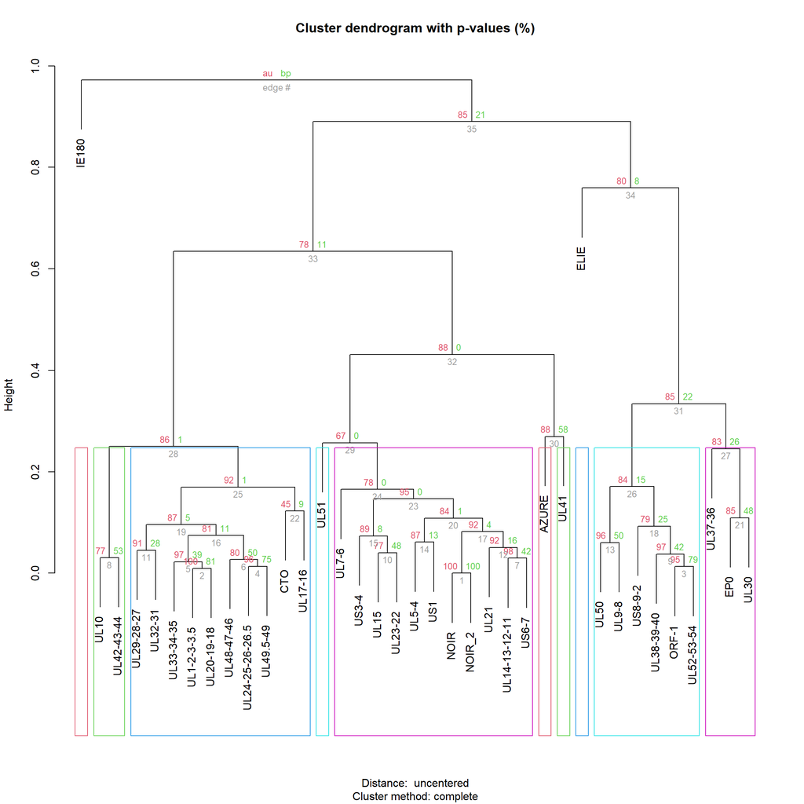

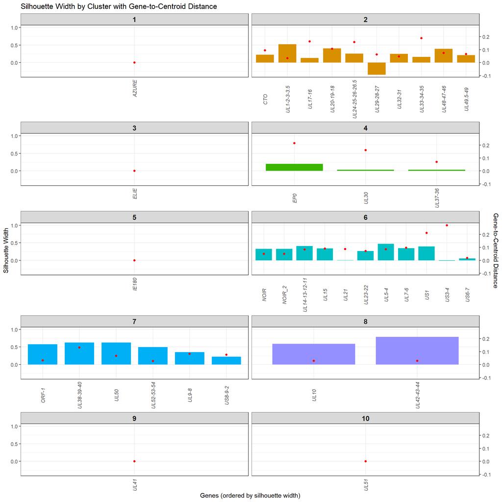

```
## Unclustered Genes, based on a Silhouette threshold of 0 and a Scaled Distance of 20:
## UL29-28-27
## US3-4
```

```
## Unclustered Genes, based on AU threshold of 0.95:
## ELIE
## NOIR
## NOIR_2
## UL14-13-12-11
## UL15
## UL21
## UL23-22
## UL5-4
## UL7-6
## US1
## US3-4
## US6-7
## UL10
## UL42-43-44
## UL51
```

#### Clustering statistics: Cluster number: 12

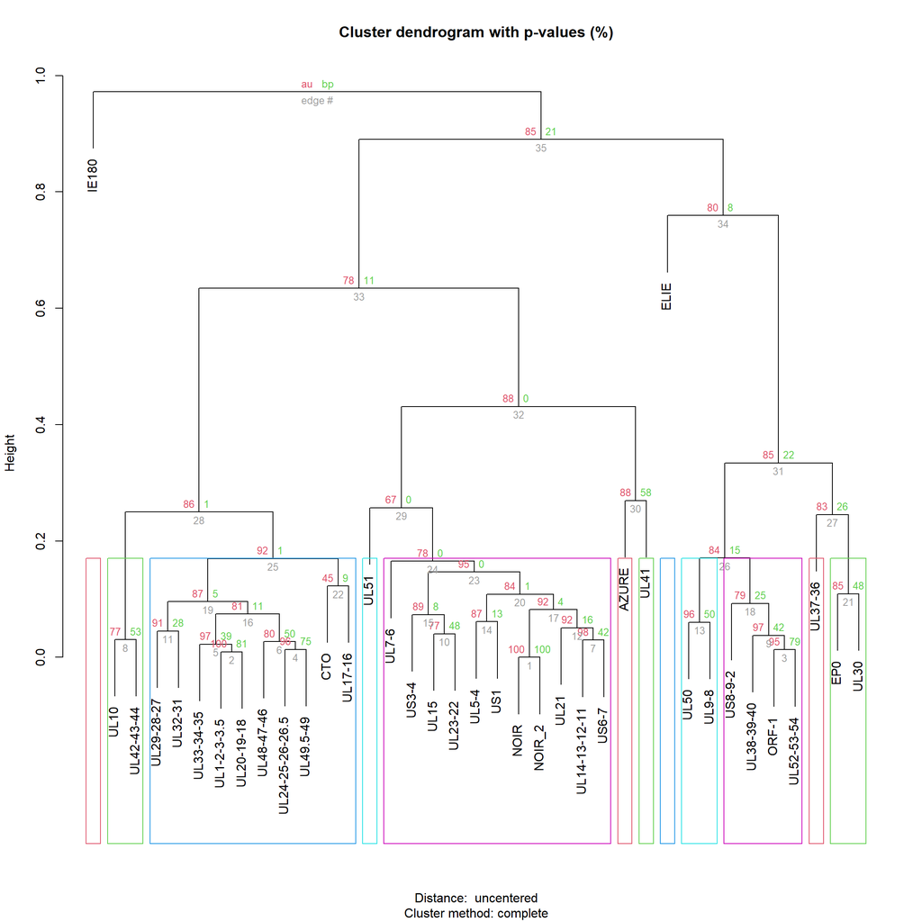

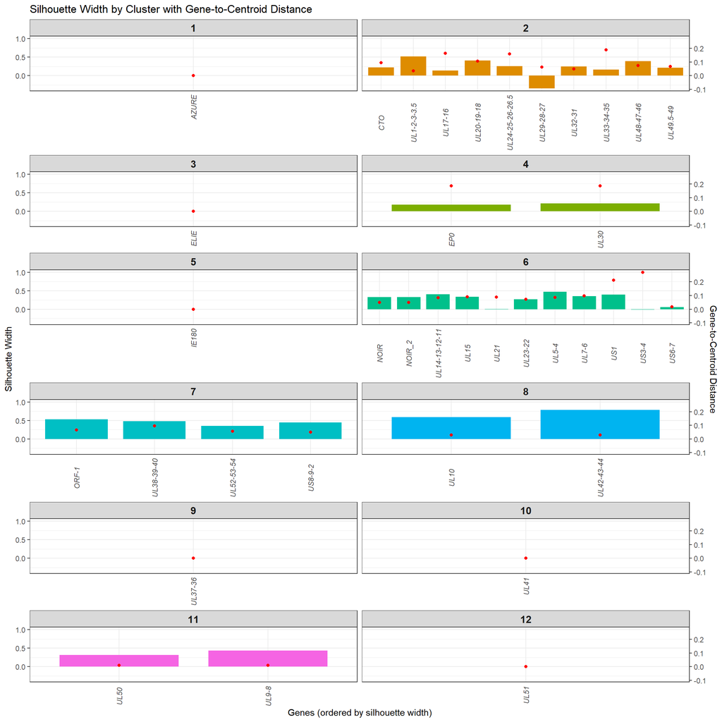

```
## Unclustered Genes, based on a Silhouette threshold of 0 and a Scaled Distance of 20:
## UL29-28-27
## US3-4
```

```
## Unclustered Genes, based on AU threshold of 0.95:
## ELIE
## NOIR
## NOIR_2
## UL14-13-12-11
## UL15
## UL21
## UL23-22
## UL5-4
## UL7-6
## US1
## US3-4
## US6-7
## UL10
## UL42-43-44
## UL41
## UL50
## UL9-8
## UL51
```

### Selected number of clusters: 12

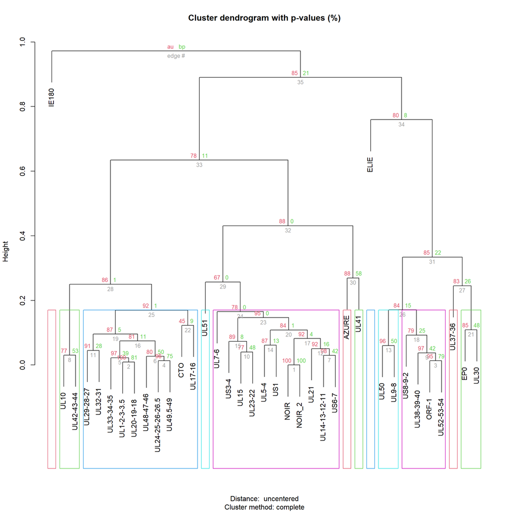

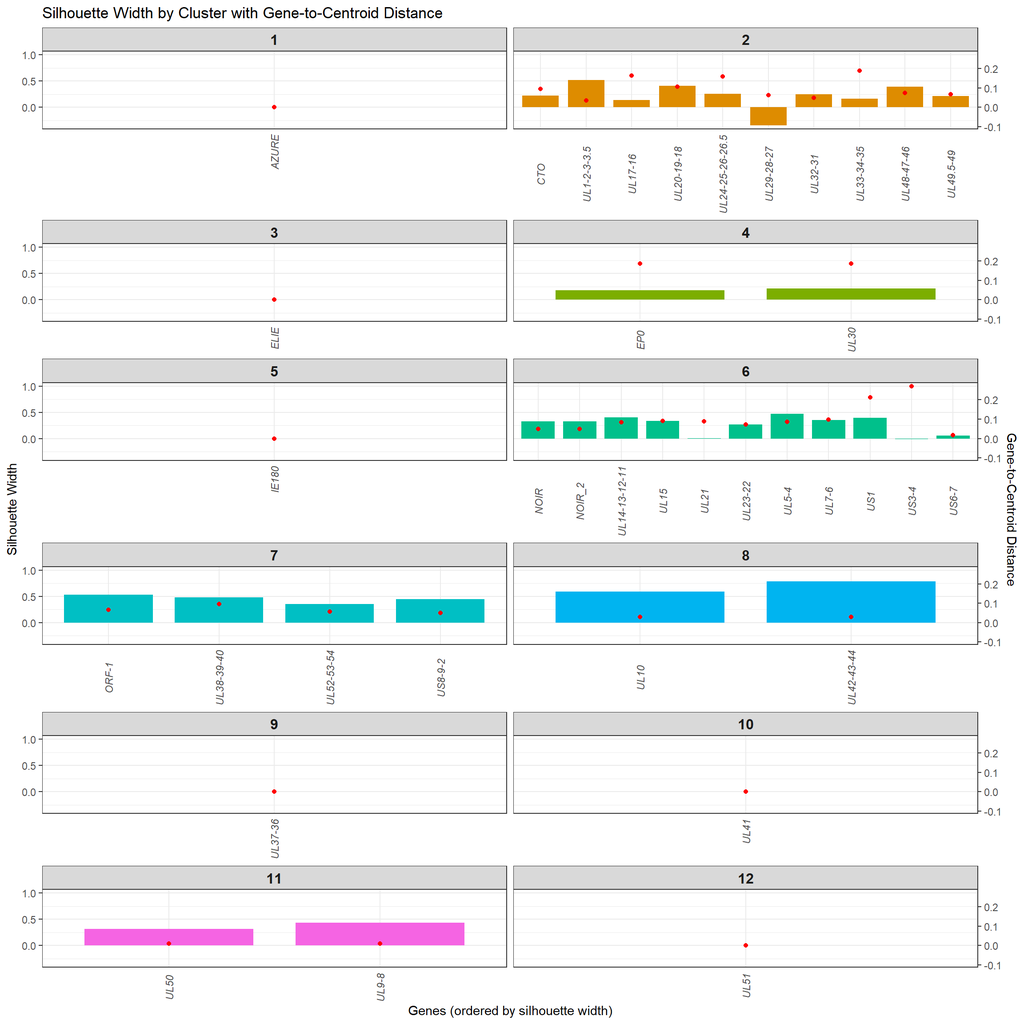

```
## Unclustered Genes, based on a Silhouette threshold of 0 and a Scaled Distance of 20:
## UL29-28-27
## US3-4
```

```
## Unclustered Genes, based on AU threshold of 0.95:
## ELIE
## NOIR
## NOIR_2
## UL14-13-12-11
## UL15
## UL21
## UL23-22
## UL5-4
## UL7-6
## US1
## US3-4
## US6-7
## UL10
## UL42-43-44
## UL41
## UL50
## UL9-8
## UL51
```

### Remove genes from clusters ?

```
##  [1] "ELIE"          "NOIR"          "NOIR_2"        "UL14-13-12-11"
##  [5] "UL15"          "UL21"          "UL23-22"       "UL5-4"
##  [9] "UL7-6"         "US1"           "US3-4"         "US6-7"
## [13] "UL10"          "UL42-43-44"    "UL41"          "UL50"
## [17] "UL9-8"         "UL51"
```

```
## [1] 18
```

```
## No genes were removed from their corresponding clusters.
```

```
##     cluster     N
##       <int> <int>
##  1:       6    11
##  2:       2    10
##  3:       7     4
##  4:       4     2
##  5:       8     2
##  6:      11     2
##  7:       1     1
##  8:       3     1
##  9:       5     1
## 10:       9     1
## 11:      10     1
## 12:      12     1
```

### Merge cluster stats

### Assigning genes to clusters

### Summarize and melt

## ORF kinetics, according to literature-based kinetic classes

Time-dependent normalized ORF counts (based on TSSs and TES clusters)

### Mean and SD with linear connection

[figure not shown]

### Each replicate with loess

[figure not shown]

### Mean and SD with loess function

## ORF kinetics, according to de-novo kinetic classes

### Figure 5 REVIEW - Mean and SD with linear connection

[figure not shown]

### Mean and SD with linear connection

[figure not shown]

### Each replicate with loess

[figure not shown]

### Mean and SD with loess function

## Combine Classes and Clusters

sum up all the (normalized) gene counts for each kinetic class in each sample (replicate) then take the mean and SD of the sums for each hpi and cell line

### Literature Kinetic Classes

#### Sum and Loess with Confidence

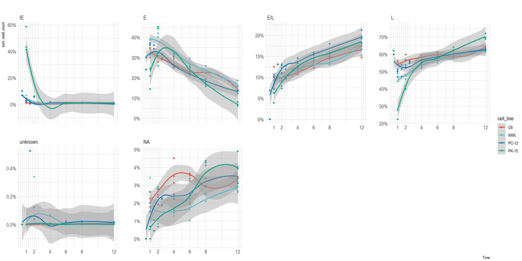

#### Mean and SD with Linear connection

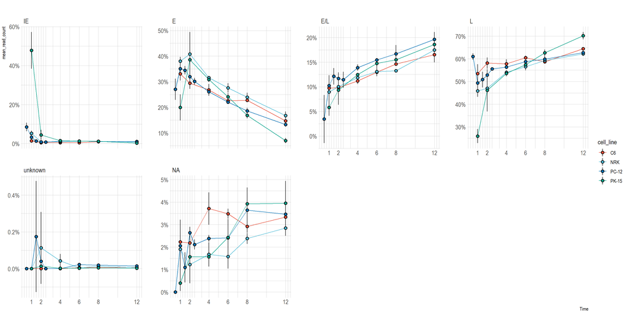

### deNovo clusters

#### Sum and Loess with Confidence

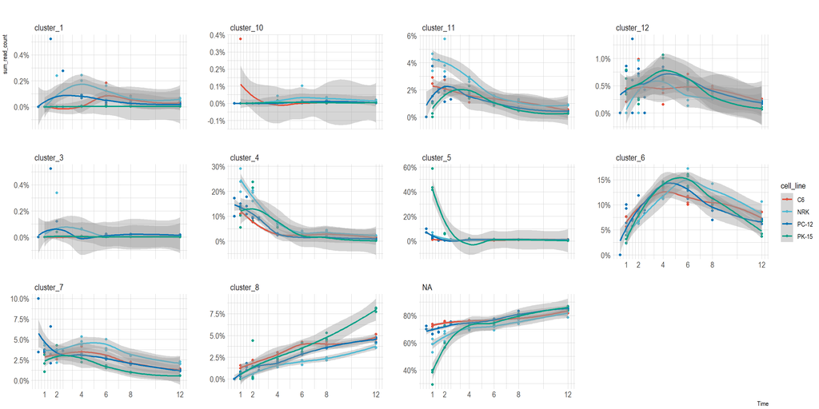

#### Mean and SD with Linear connection

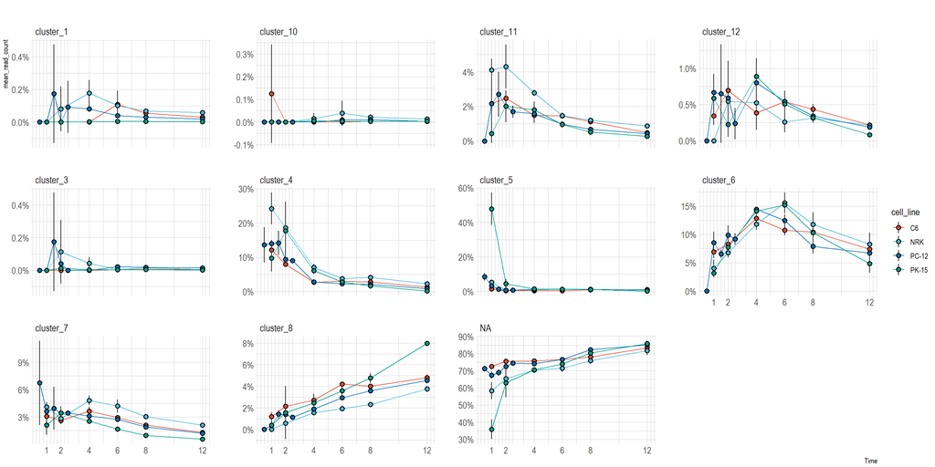

## Compare literature and de novo kinetic classes

*NA shows the number of genes where the clustering did not yield an unambiguous result.*

### each gene 1

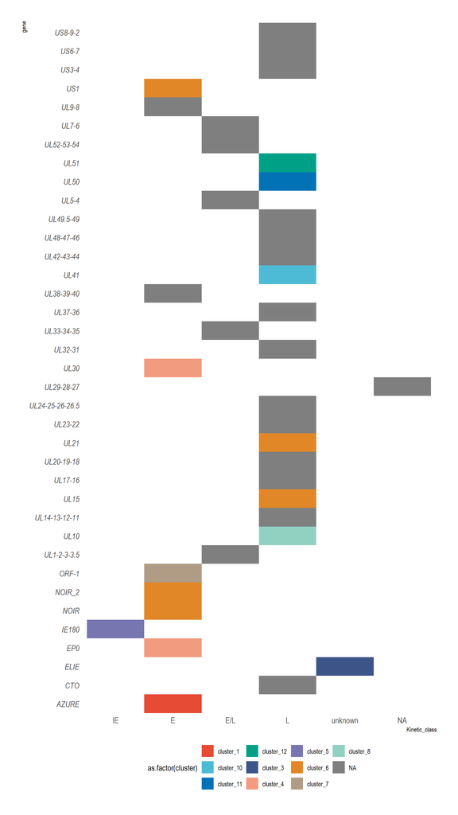

### each gene 2

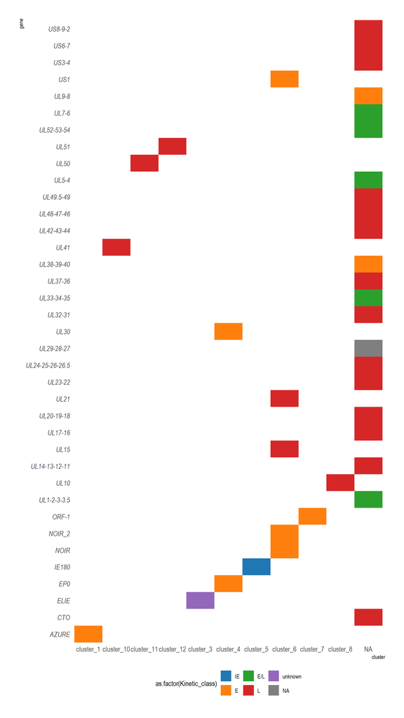

### summary

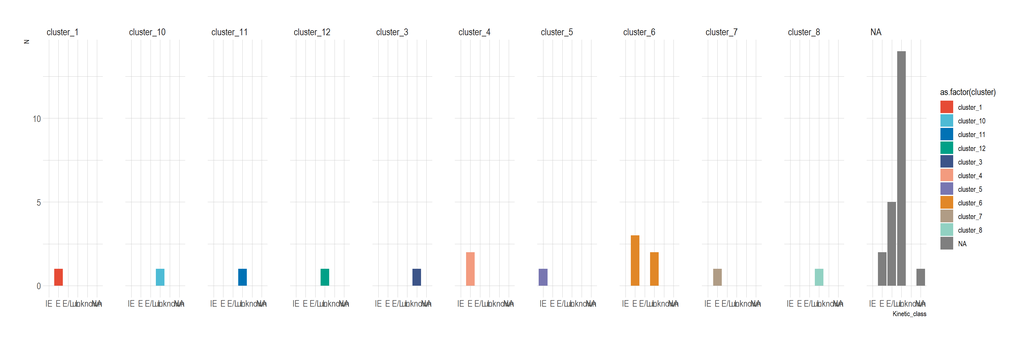

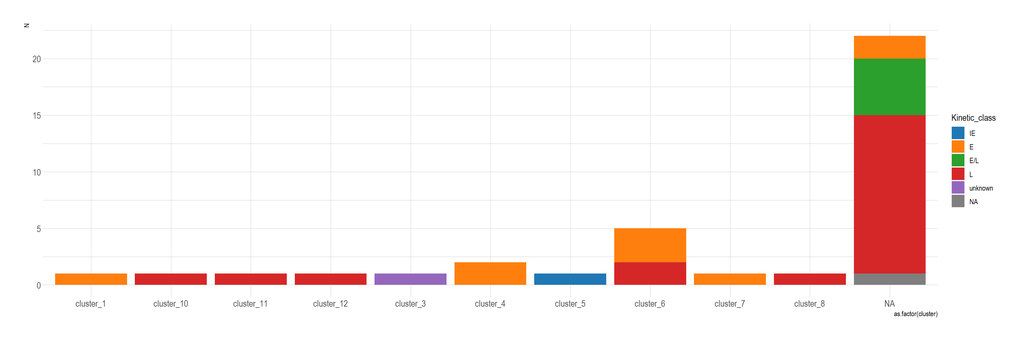

## Literature Clusters and Selected Genes

### Reps with loess and confidence

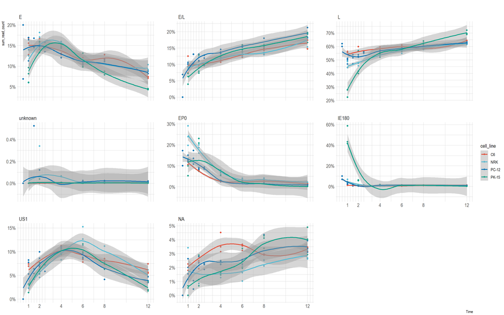

### Means with SD and linear connection

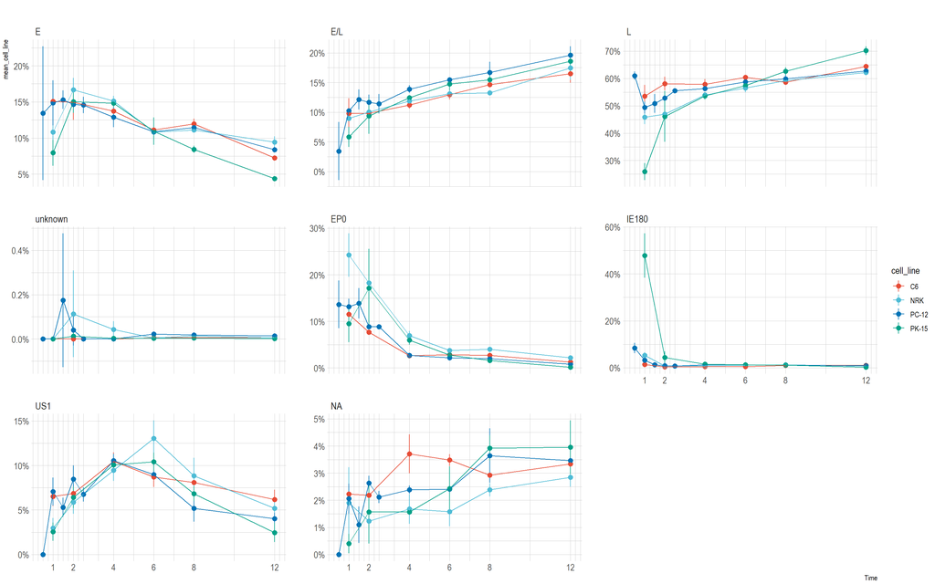

## Gene-pair ratios

### Means with SD and linear connection

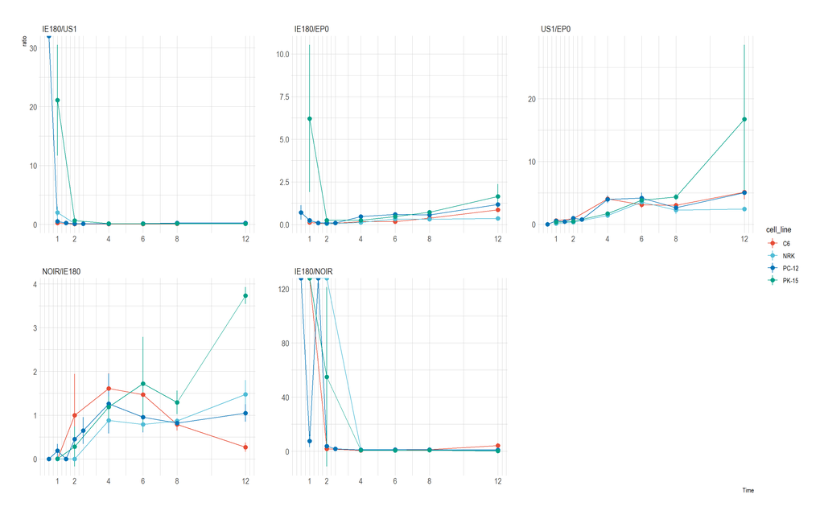

### Log10 Means with SD and linear connection

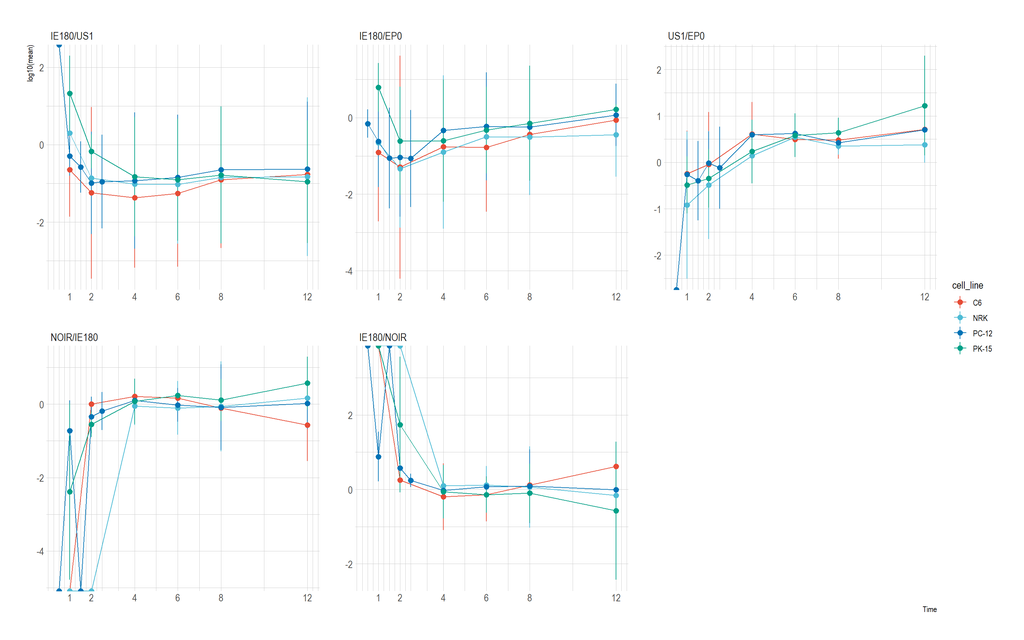

### Reps with loess and confidence

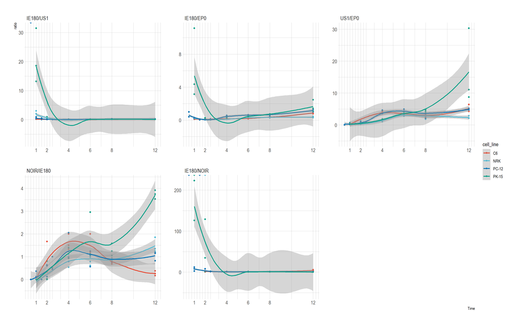

### Sums with linear connection

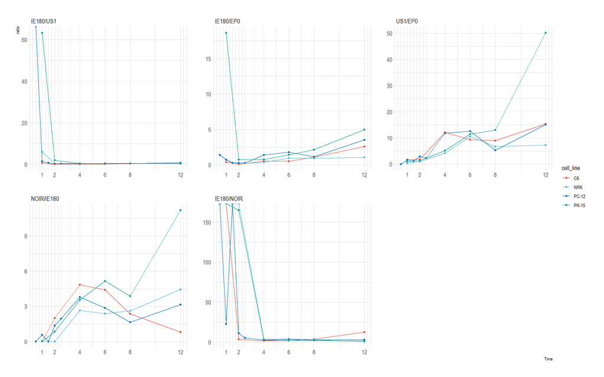